# Eflows Species Clustering in CA Regions

## Overview and Basic Methods

In this version (June 2018) of the clustering, translocations were *not* included. Clusters must be contiguous in this version, as determined by a shared boundary or vertex, not by hydrologic connectivity. All HUCs were included, regardless of the minimum number of taxa (includes ones with one or none). Clustering was done with Flow Sensitive Taxa.

Clustering was done by a PISCES tool that subsets and formulates the data to be used by ArcGIS’ Grouping Analysis tool, where prior versions were clustered through manual steps and then fed into GeoDa’s K-Means tool.

## Map of Region Breakouts

The region was broken out primarily into * North Coast (North Coast->San Francisco) * South Coast (South of SF -> Southern California) * Central Valley (anything draining out through the Central Valley - excludes Honey/Eagle Lakes and SF Bay) * Great Basin (anything in hydrologic region 16 in the northern part of the state, contiguous) * Desert - not clustered or shown here as previous clustering indicated single-species driven areas (Includes eastern sierra that is part of region 18, souther reaches of region 15 in the state, portion of Colorado River, and a small piece of region 16)

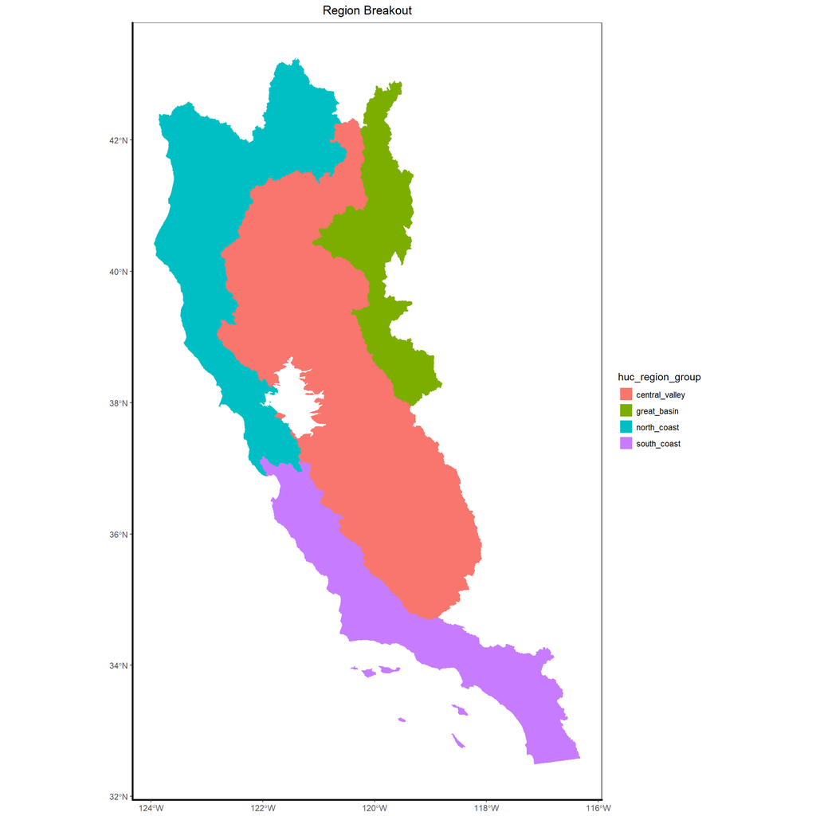

```r
writeLines("td, th { padding : 6px } th { background-color : #fff ; color : #000; border : 1px solid #333; } td { color : #000 ; border : 1px solid #333 }", con = "mystyle.css")  # add the CSS for the data tables

ggplot() +
  geom_sf(huc_data, lwd = 5, mapping=aes(fill=huc_region_group), color=NA)+
  ggtitle("Region Breakout") +
  theme_bw()+
  theme(panel.grid.major = element_line(colour = 'transparent'))+
  theme(strip.background = element_blank(), # facet theme control
        strip.placement = "outside",
        axis.line.x = element_line(color="black", size = 1),
        axis.line.y = element_line(color="black", size = 1),
        plot.title = element_text(hjust = 0.5))
```

## Central Valley

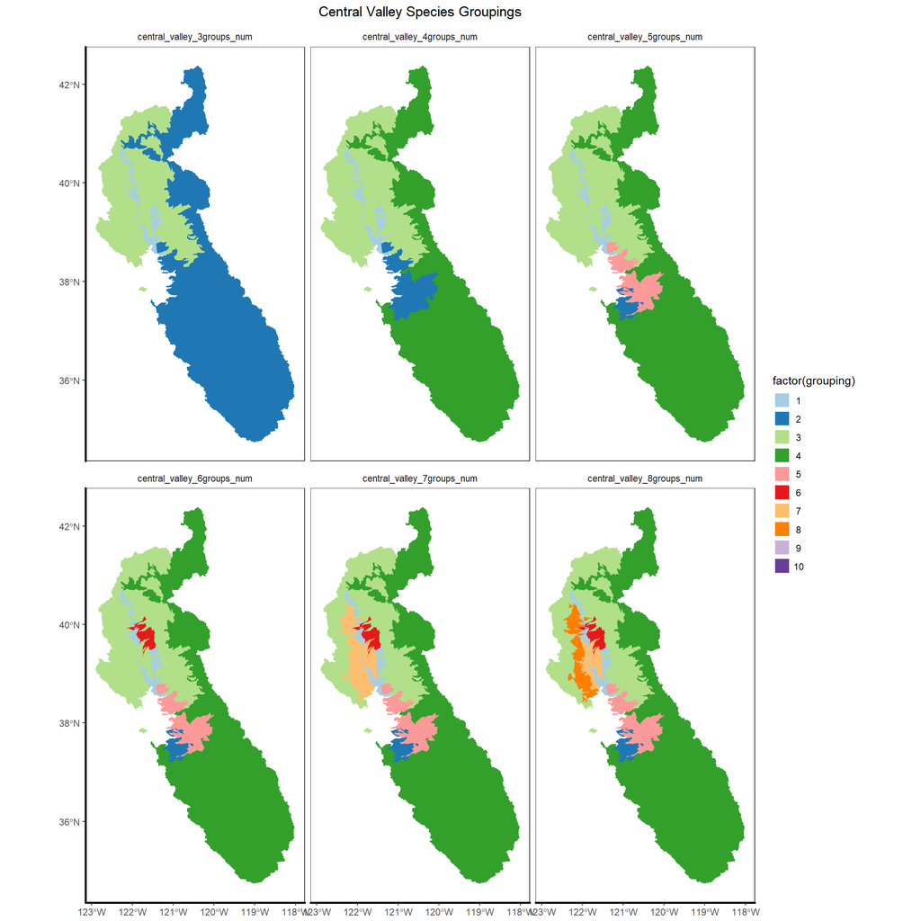

```r
cv_region_name = "central_valley"
cv_species_info <- species_maps(cv_region_name, "Central Valley", huc_data)
cv_species_info$region_map  # print the map
```

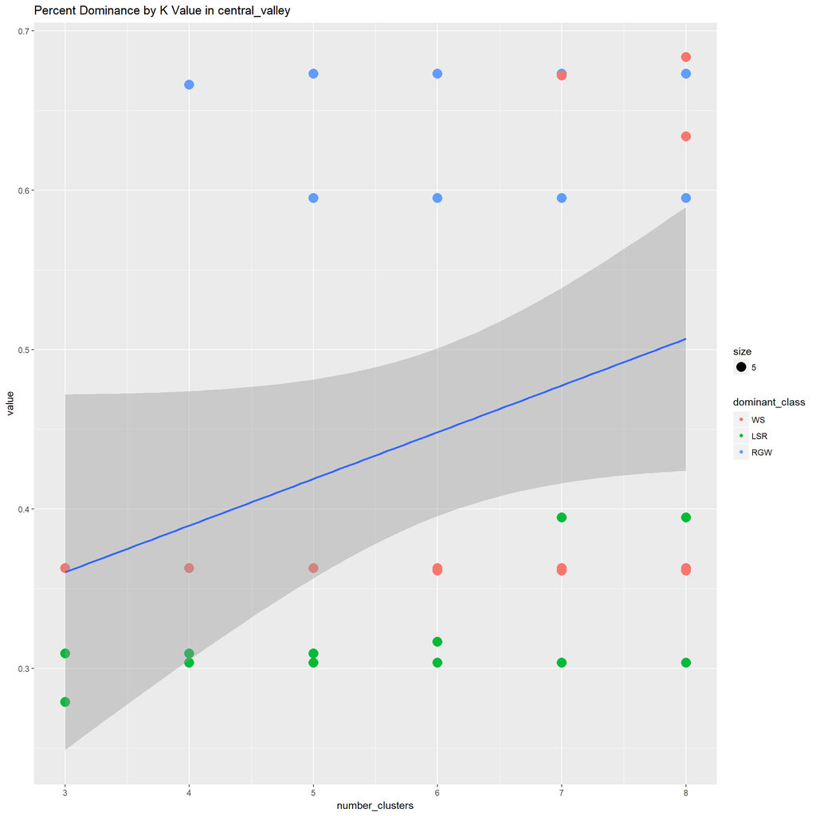

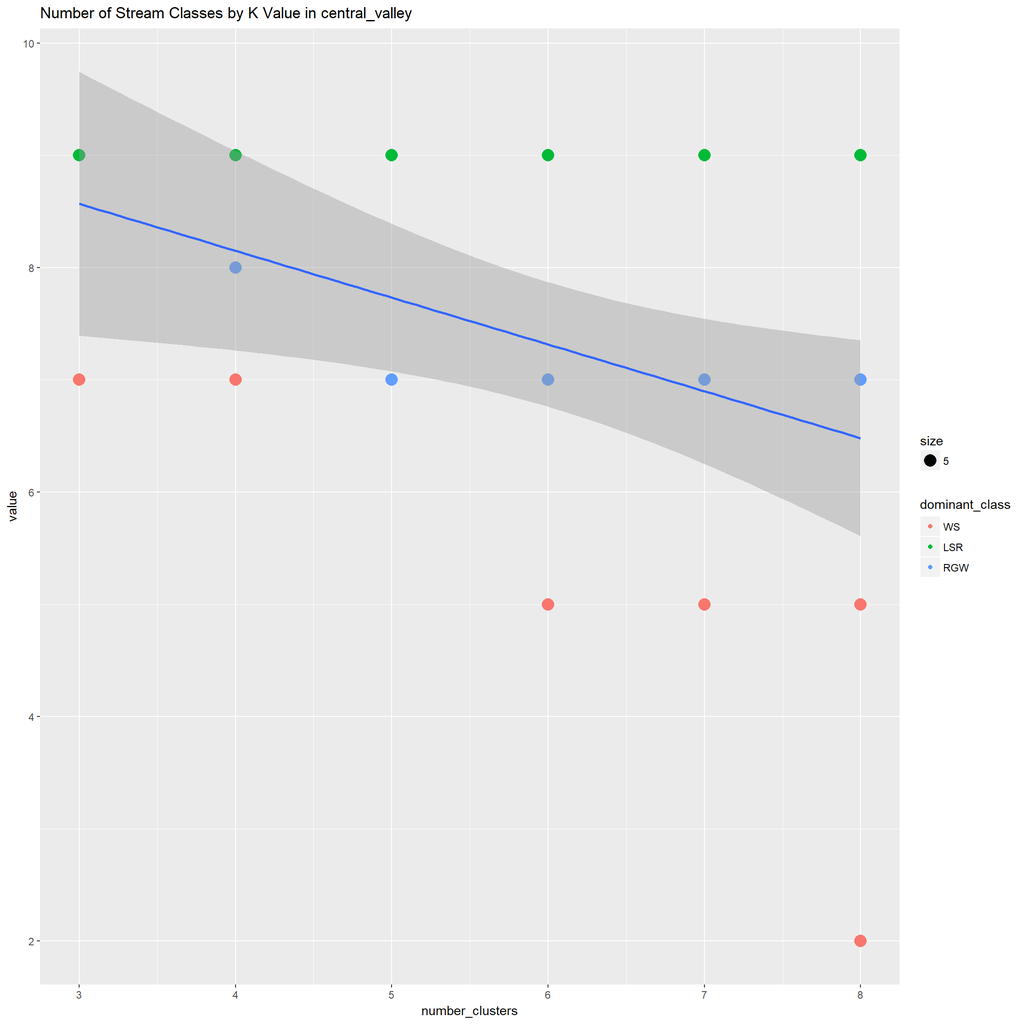

```r
print_dominance_plots(cv_species_info, cv_region_name)
```

```r
cv_species_lists <- species_lists_by_group_dfs(cv_species_info$species_data, cv_region_name)  # species_info$species_data is the data frame for the region
for(df in cv_species_lists){
  show(knitr::kable(df, format="html"))
}
```

| group_1 | group_2 | group_3 |
| --- | --- | --- |
| acipenser | acipenser | acipenser |
| catostomus | catostomus | catostomus |
| cottus | cottus | cottus |
| entosphenus | entosphenus | entosphenus |
| gasterosteus | gasterosteus | gasterosteus |
| hesperoleucus | hesperoleucus | hesperoleucus |
| hysterocarpus | hysterocarpus | hysterocarpus |
| lampetra | lampetra | lampetra |
| lavinia | lavinia | lavinia |
| mylopharodon | mylopharodon | mylopharodon |
| oncorhynchus | oncorhynchus | oncorhynchus |
| pogonichthys | pogonichthys | pogonichthys |
| ptychocheilus | ptychocheilus | ptychocheilus |
| rhinichthys | rhinichthys | rhinichthys |

| group_1 | group_2 | group_3 | group_4 |
| --- | --- | --- | --- |
| acipenser | acipenser | acipenser | catostomus |
| catostomus | catostomus | catostomus | cottus |
| cottus | cottus | cottus | entosphenus |
| entosphenus | entosphenus | entosphenus | gasterosteus |
| gasterosteus | gasterosteus | gasterosteus | hesperoleucus |
| hesperoleucus | hesperoleucus | hesperoleucus | hysterocarpus |
| hysterocarpus | hysterocarpus | hysterocarpus | lampetra |
| lampetra | lampetra | lampetra | lavinia |
| lavinia | lavinia | lavinia | mylopharodon |
| mylopharodon | mylopharodon | mylopharodon | oncorhynchus |
| oncorhynchus | oncorhynchus | oncorhynchus | pogonichthys |
| pogonichthys | pogonichthys | pogonichthys | ptychocheilus |
| ptychocheilus | ptychocheilus | ptychocheilus | rhinichthys |
| rhinichthys | NA | rhinichthys | NA |

| group_1 | group_2 | group_3 | group_4 | group_5 |
| --- | --- | --- | --- | --- |
| acipenser | acipenser | acipenser | catostomus | catostomus |
| catostomus | catostomus | catostomus | cottus | cottus |
| cottus | cottus | cottus | entosphenus | entosphenus |
| entosphenus | entosphenus | entosphenus | gasterosteus | gasterosteus |
| gasterosteus | gasterosteus | gasterosteus | hesperoleucus | hesperoleucus |
| hesperoleucus | hysterocarpus | hesperoleucus | hysterocarpus | hysterocarpus |
| hysterocarpus | lampetra | hysterocarpus | lampetra | lampetra |
| lampetra | lavinia | lampetra | lavinia | lavinia |
| lavinia | mylopharodon | lavinia | mylopharodon | mylopharodon |
| mylopharodon | oncorhynchus | mylopharodon | oncorhynchus | oncorhynchus |
| oncorhynchus | pogonichthys | oncorhynchus | pogonichthys | pogonichthys |
| pogonichthys | ptychocheilus | pogonichthys | ptychocheilus | ptychocheilus |
| ptychocheilus | NA | ptychocheilus | rhinichthys | NA |
| rhinichthys | NA | rhinichthys | NA | NA |

| group_1 | group_2 | group_3 | group_4 | group_5 | group_6 |
| --- | --- | --- | --- | --- | --- |
| acipenser | acipenser | acipenser | catostomus | catostomus | catostomus |
| catostomus | catostomus | catostomus | cottus | cottus | cottus |
| cottus | cottus | cottus | entosphenus | entosphenus | entosphenus |
| entosphenus | entosphenus | entosphenus | gasterosteus | gasterosteus | gasterosteus |
| gasterosteus | gasterosteus | gasterosteus | hesperoleucus | hesperoleucus | hesperoleucus |
| hesperoleucus | hysterocarpus | hesperoleucus | hysterocarpus | hysterocarpus | hysterocarpus |
| hysterocarpus | lampetra | hysterocarpus | lampetra | lampetra | lampetra |
| lampetra | lavinia | lampetra | lavinia | lavinia | lavinia |
| lavinia | mylopharodon | lavinia | mylopharodon | mylopharodon | mylopharodon |
| mylopharodon | oncorhynchus | mylopharodon | oncorhynchus | oncorhynchus | oncorhynchus |
| oncorhynchus | pogonichthys | oncorhynchus | pogonichthys | pogonichthys | ptychocheilus |
| pogonichthys | ptychocheilus | pogonichthys | ptychocheilus | ptychocheilus | rhinichthys |
| ptychocheilus | NA | ptychocheilus | rhinichthys | NA | NA |
| rhinichthys | NA | rhinichthys | NA | NA | NA |

| group_1 | group_2 | group_3 | group_4 | group_5 | group_6 | group_7 |
| --- | --- | --- | --- | --- | --- | --- |
| acipenser | acipenser | acipenser | catostomus | catostomus | catostomus | catostomus |
| catostomus | catostomus | catostomus | cottus | cottus | cottus | cottus |
| cottus | cottus | cottus | entosphenus | entosphenus | entosphenus | entosphenus |
| entosphenus | entosphenus | entosphenus | gasterosteus | gasterosteus | gasterosteus | gasterosteus |
| gasterosteus | gasterosteus | gasterosteus | hesperoleucus | hesperoleucus | hesperoleucus | hesperoleucus |
| hesperoleucus | hysterocarpus | hesperoleucus | hysterocarpus | hysterocarpus | hysterocarpus | hysterocarpus |
| hysterocarpus | lampetra | hysterocarpus | lampetra | lampetra | lampetra | lampetra |
| lampetra | lavinia | lampetra | lavinia | lavinia | lavinia | lavinia |
| lavinia | mylopharodon | lavinia | mylopharodon | mylopharodon | mylopharodon | mylopharodon |
| mylopharodon | oncorhynchus | mylopharodon | oncorhynchus | oncorhynchus | oncorhynchus | oncorhynchus |
| oncorhynchus | pogonichthys | oncorhynchus | pogonichthys | pogonichthys | ptychocheilus | pogonichthys |
| pogonichthys | ptychocheilus | pogonichthys | ptychocheilus | ptychocheilus | rhinichthys | ptychocheilus |
| ptychocheilus | NA | ptychocheilus | rhinichthys | NA | NA | rhinichthys |
| rhinichthys | NA | rhinichthys | NA | NA | NA | NA |

| group_1 | group_2 | group_3 | group_4 | group_5 | group_6 | group_7 | group_8 |
| --- | --- | --- | --- | --- | --- | --- | --- |
| acipenser | acipenser | acipenser | catostomus | catostomus | catostomus | catostomus | catostomus |
| catostomus | catostomus | catostomus | cottus | cottus | cottus | cottus | cottus |
| cottus | cottus | cottus | entosphenus | entosphenus | entosphenus | entosphenus | entosphenus |
| entosphenus | entosphenus | entosphenus | gasterosteus | gasterosteus | gasterosteus | gasterosteus | gasterosteus |
| gasterosteus | gasterosteus | gasterosteus | hesperoleucus | hesperoleucus | hesperoleucus | hesperoleucus | hesperoleucus |
| hesperoleucus | hysterocarpus | hesperoleucus | hysterocarpus | hysterocarpus | hysterocarpus | hysterocarpus | hysterocarpus |
| hysterocarpus | lampetra | hysterocarpus | lampetra | lampetra | lampetra | lampetra | lampetra |
| lampetra | lavinia | lampetra | lavinia | lavinia | lavinia | lavinia | lavinia |
| lavinia | mylopharodon | lavinia | mylopharodon | mylopharodon | mylopharodon | mylopharodon | mylopharodon |
| mylopharodon | oncorhynchus | mylopharodon | oncorhynchus | oncorhynchus | oncorhynchus | oncorhynchus | oncorhynchus |
| oncorhynchus | pogonichthys | oncorhynchus | pogonichthys | pogonichthys | ptychocheilus | pogonichthys | ptychocheilus |
| pogonichthys | ptychocheilus | pogonichthys | ptychocheilus | ptychocheilus | rhinichthys | ptychocheilus | rhinichthys |
| ptychocheilus | NA | ptychocheilus | rhinichthys | NA | NA | rhinichthys | NA |
| rhinichthys | NA | rhinichthys | NA | NA | NA | NA | NA |

## Great Basin

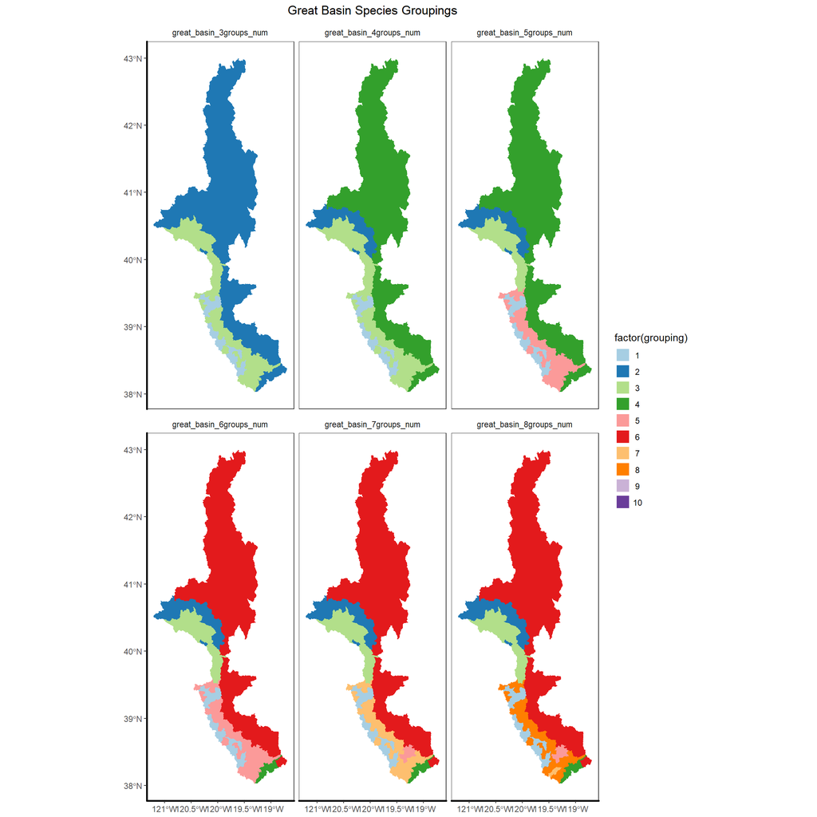

```r
gb_region_name <- "great_basin"
gb_species_info <- species_maps(gb_region_name, "Great Basin", huc_data)
gb_species_info$region_map  # print the map
```

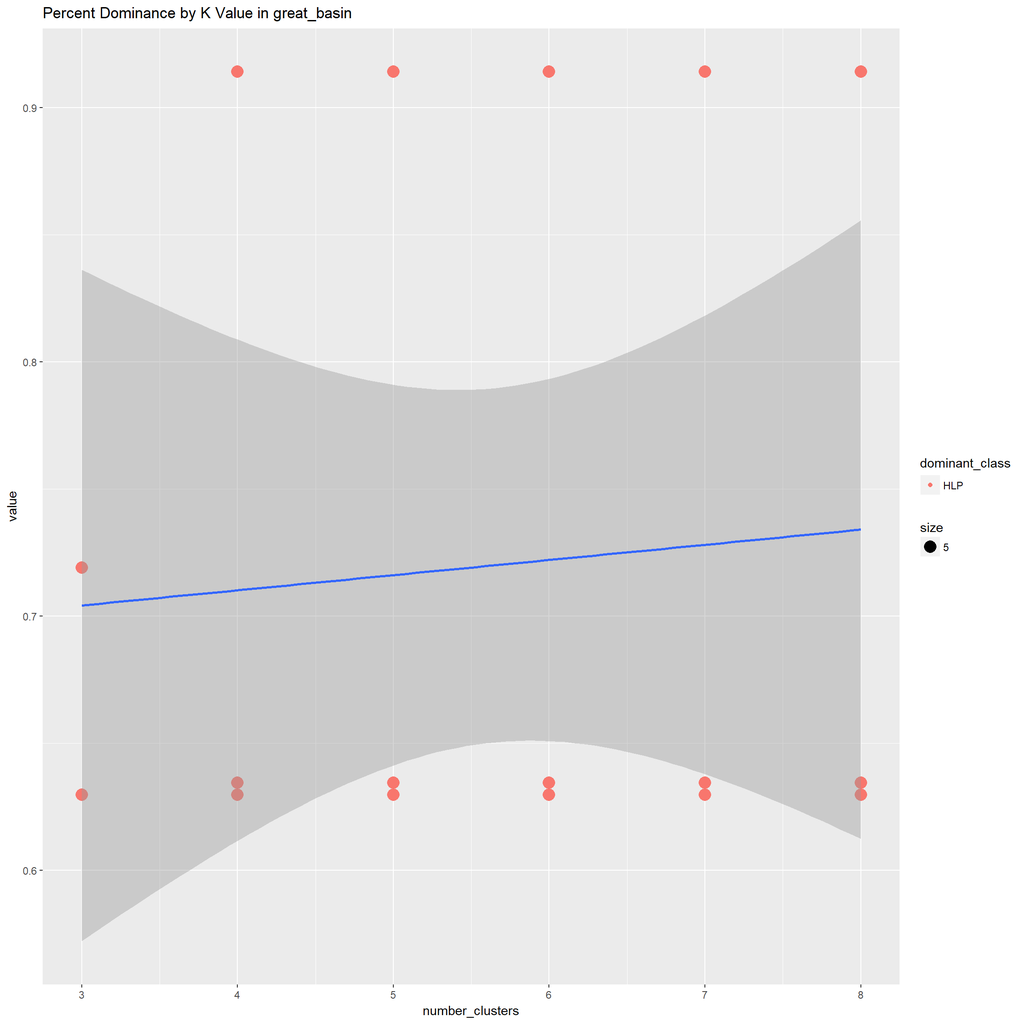

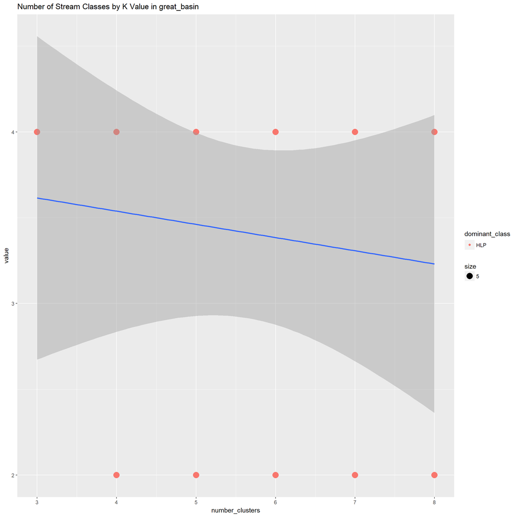

```r
print_dominance_plots(gb_species_info, gb_region_name)
```

```r
gb_species_lists <- species_lists_by_group_dfs(gb_species_info$species_data, gb_region_name)  # species_info$species_data is the data frame for the region
for(df in gb_species_lists){
  show(knitr::kable(df, format="html"))
}
```

| group_1 | group_2 | group_3 |
| --- | --- | --- |
| oncorhynchus | pantosteus | oncorhynchus |
| pantosteus | rhinichthys | pantosteus |
| prosopium | NA | prosopium |
| rhinichthys | NA | rhinichthys |

| group_1 | group_2 | group_3 | group_4 |
| --- | --- | --- | --- |
| oncorhynchus | rhinichthys | oncorhynchus | pantosteus |
| pantosteus | NA | pantosteus | rhinichthys |
| prosopium | NA | prosopium | NA |
| rhinichthys | NA | rhinichthys | NA |

| group_1 | group_2 | group_3 | group_4 | group_5 |
| --- | --- | --- | --- | --- |
| oncorhynchus | rhinichthys | pantosteus | pantosteus | oncorhynchus |
| pantosteus | NA | rhinichthys | rhinichthys | pantosteus |
| prosopium | NA | NA | NA | prosopium |
| rhinichthys | NA | NA | NA | rhinichthys |

| group_1 | group_2 | group_3 | group_4 | group_5 | group_6 |
| --- | --- | --- | --- | --- | --- |
| oncorhynchus | rhinichthys | pantosteus | pantosteus | oncorhynchus | rhinichthys |
| pantosteus | NA | rhinichthys | rhinichthys | pantosteus | NA |
| prosopium | NA | NA | NA | prosopium | NA |
| rhinichthys | NA | NA | NA | rhinichthys | NA |

| group_1 | group_2 | group_3 | group_4 | group_5 | group_6 | group_7 |
| --- | --- | --- | --- | --- | --- | --- |
| oncorhynchus | rhinichthys | pantosteus | pantosteus | pantosteus | rhinichthys | oncorhynchus |
| pantosteus | NA | rhinichthys | rhinichthys | rhinichthys | NA | pantosteus |
| prosopium | NA | NA | NA | NA | NA | prosopium |
| rhinichthys | NA | NA | NA | NA | NA | rhinichthys |

| group_1 | group_2 | group_3 | group_4 | group_5 | group_6 | group_7 | group_8 |
| --- | --- | --- | --- | --- | --- | --- | --- |
| oncorhynchus | rhinichthys | pantosteus | pantosteus | pantosteus | rhinichthys | oncorhynchus | oncorhynchus |
| pantosteus | NA | rhinichthys | rhinichthys | rhinichthys | NA | pantosteus | pantosteus |
| prosopium | NA | NA | NA | NA | NA | prosopium | prosopium |
| rhinichthys | NA | NA | NA | NA | NA | rhinichthys | rhinichthys |

## North Coast

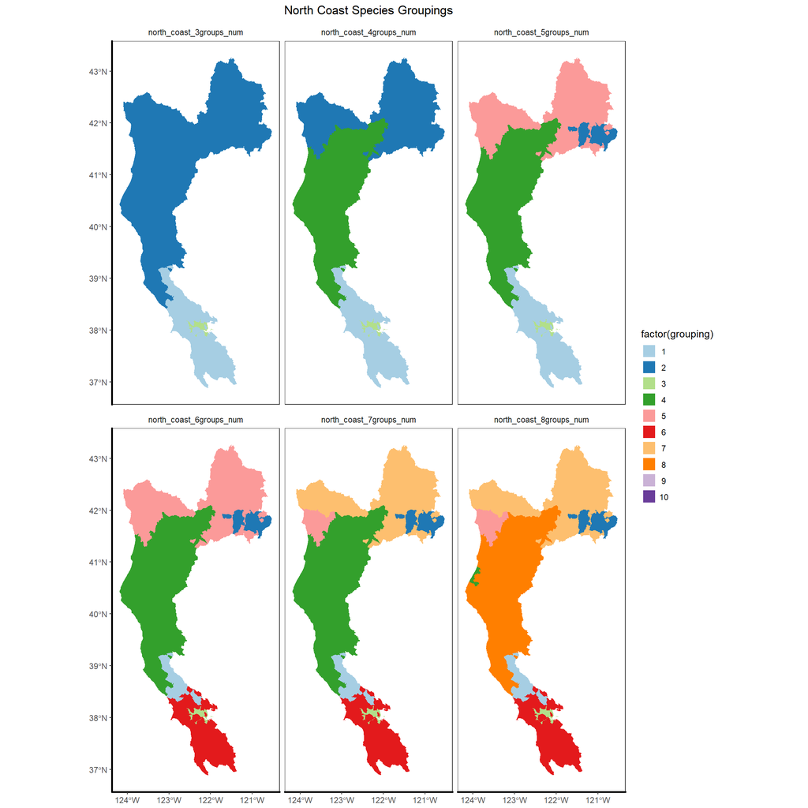

```r
coast_region_name = "north_coast"
coast_species_info <- species_maps(coast_region_name, "North Coast", huc_data)
coast_species_info$region_map  # print the map
```

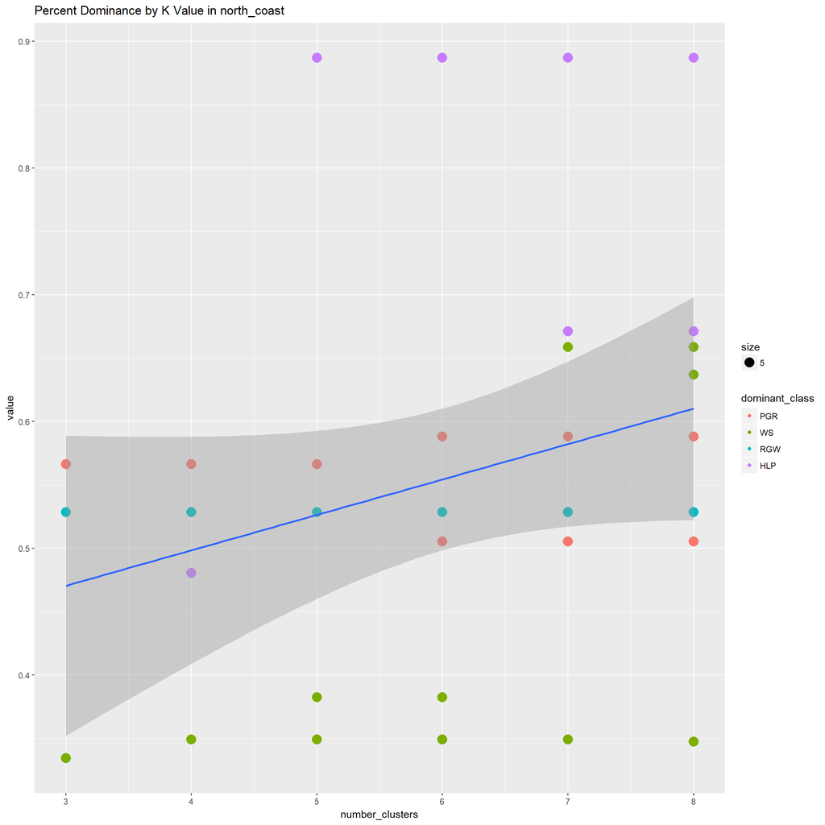

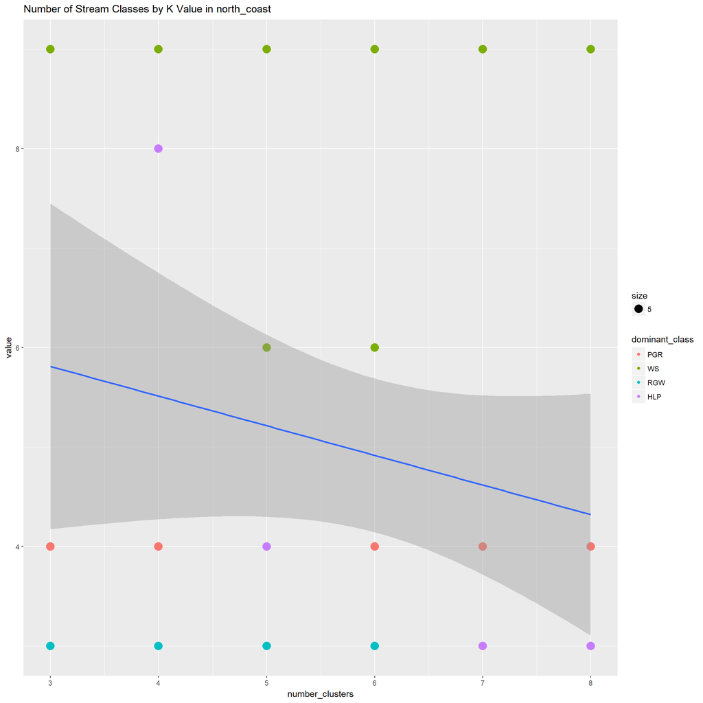

```r
print_dominance_plots(coast_species_info, coast_region_name)
```

```r
coast_species_lists <- species_lists_by_group_dfs(coast_species_info$species_data, coast_region_name)  # species_info$species_data is the data frame for the region
for(df in coast_species_lists){
  show(knitr::kable(df, format="html"))
}
```

| group_1 | group_2 | group_3 |
| --- | --- | --- |
| acipenser | acipenser | acipenser |
| catostomus | catostomus | catostomus |
| cottus | chasmistes | entosphenus |
| entosphenus | cottus | gasterosteus |
| eucyclogobius | entosphenus | hesperoleucus |
| gasterosteus | eucyclogobius | hypomesus |
| hesperoleucus | gasterosteus | hysterocarpus |
| hypomesus | gila | lampetra |
| hysterocarpus | lampetra | lavinia |
| lampetra | oncorhynchus | mylopharodon |
| lavinia | ptychocheilus | oncorhynchus |
| mylopharodon | spirinchus | pogonichthys |
| oncorhynchus | NA | ptychocheilus |
| pogonichthys | NA | NA |
| ptychocheilus | NA | NA |
| spirinchus | NA | NA |

| group_1 | group_2 | group_3 | group_4 |
| --- | --- | --- | --- |
| acipenser | acipenser | acipenser | acipenser |
| catostomus | catostomus | catostomus | catostomus |
| cottus | chasmistes | entosphenus | chasmistes |
| entosphenus | cottus | gasterosteus | cottus |
| eucyclogobius | entosphenus | hesperoleucus | entosphenus |
| gasterosteus | eucyclogobius | hypomesus | eucyclogobius |
| hesperoleucus | gasterosteus | hysterocarpus | gasterosteus |
| hypomesus | gila | lampetra | lampetra |
| hysterocarpus | lampetra | lavinia | oncorhynchus |
| lampetra | oncorhynchus | mylopharodon | ptychocheilus |
| lavinia | NA | oncorhynchus | spirinchus |
| mylopharodon | NA | pogonichthys | NA |
| oncorhynchus | NA | ptychocheilus | NA |
| pogonichthys | NA | NA | NA |
| ptychocheilus | NA | NA | NA |
| spirinchus | NA | NA | NA |

| group_1 | group_2 | group_3 | group_4 | group_5 |
| --- | --- | --- | --- | --- |
| acipenser | catostomus | acipenser | acipenser | acipenser |
| catostomus | chasmistes | catostomus | catostomus | catostomus |
| cottus | cottus | entosphenus | chasmistes | chasmistes |
| entosphenus | gila | gasterosteus | cottus | cottus |
| eucyclogobius | NA | hesperoleucus | entosphenus | entosphenus |
| gasterosteus | NA | hypomesus | eucyclogobius | eucyclogobius |
| hesperoleucus | NA | hysterocarpus | gasterosteus | gasterosteus |
| hypomesus | NA | lampetra | lampetra | lampetra |
| hysterocarpus | NA | lavinia | oncorhynchus | oncorhynchus |
| lampetra | NA | mylopharodon | ptychocheilus | NA |
| lavinia | NA | oncorhynchus | spirinchus | NA |
| mylopharodon | NA | pogonichthys | NA | NA |
| oncorhynchus | NA | ptychocheilus | NA | NA |
| pogonichthys | NA | NA | NA | NA |
| ptychocheilus | NA | NA | NA | NA |
| spirinchus | NA | NA | NA | NA |

| group_1 | group_2 | group_3 | group_4 | group_5 | group_6 |
| --- | --- | --- | --- | --- | --- |
| acipenser | catostomus | acipenser | acipenser | acipenser | acipenser |
| catostomus | chasmistes | catostomus | catostomus | catostomus | catostomus |
| cottus | cottus | entosphenus | chasmistes | chasmistes | cottus |
| entosphenus | gila | gasterosteus | cottus | cottus | entosphenus |
| gasterosteus | NA | hesperoleucus | entosphenus | entosphenus | eucyclogobius |
| hesperoleucus | NA | hypomesus | eucyclogobius | eucyclogobius | gasterosteus |
| hysterocarpus | NA | hysterocarpus | gasterosteus | gasterosteus | hesperoleucus |
| lampetra | NA | lampetra | lampetra | lampetra | hypomesus |
| lavinia | NA | lavinia | oncorhynchus | oncorhynchus | hysterocarpus |
| mylopharodon | NA | mylopharodon | ptychocheilus | NA | lampetra |
| oncorhynchus | NA | oncorhynchus | spirinchus | NA | lavinia |
| ptychocheilus | NA | pogonichthys | NA | NA | mylopharodon |
| spirinchus | NA | ptychocheilus | NA | NA | oncorhynchus |
| NA | NA | NA | NA | NA | pogonichthys |
| NA | NA | NA | NA | NA | ptychocheilus |
| NA | NA | NA | NA | NA | spirinchus |

| group_1 | group_2 | group_3 | group_4 | group_5 | group_6 | group_7 |
| --- | --- | --- | --- | --- | --- | --- |
| acipenser | catostomus | acipenser | acipenser | acipenser | acipenser | catostomus |
| catostomus | chasmistes | catostomus | catostomus | entosphenus | catostomus | chasmistes |
| cottus | cottus | entosphenus | chasmistes | eucyclogobius | cottus | cottus |
| entosphenus | gila | gasterosteus | cottus | gasterosteus | entosphenus | entosphenus |
| gasterosteus | NA | hesperoleucus | entosphenus | lampetra | eucyclogobius | oncorhynchus |
| hesperoleucus | NA | hypomesus | eucyclogobius | oncorhynchus | gasterosteus | NA |
| hysterocarpus | NA | hysterocarpus | gasterosteus | NA | hesperoleucus | NA |
| lampetra | NA | lampetra | lampetra | NA | hypomesus | NA |
| lavinia | NA | lavinia | oncorhynchus | NA | hysterocarpus | NA |
| mylopharodon | NA | mylopharodon | ptychocheilus | NA | lampetra | NA |
| oncorhynchus | NA | oncorhynchus | spirinchus | NA | lavinia | NA |
| ptychocheilus | NA | pogonichthys | NA | NA | mylopharodon | NA |
| spirinchus | NA | ptychocheilus | NA | NA | oncorhynchus | NA |
| NA | NA | NA | NA | NA | pogonichthys | NA |
| NA | NA | NA | NA | NA | ptychocheilus | NA |
| NA | NA | NA | NA | NA | spirinchus | NA |

| group_1 | group_2 | group_3 | group_4 | group_5 | group_6 | group_7 | group_8 |
| --- | --- | --- | --- | --- | --- | --- | --- |
| acipenser | catostomus | acipenser | acipenser | acipenser | acipenser | catostomus | acipenser |
| catostomus | chasmistes | catostomus | entosphenus | entosphenus | catostomus | chasmistes | catostomus |
| cottus | cottus | entosphenus | eucyclogobius | eucyclogobius | cottus | cottus | chasmistes |
| entosphenus | gila | gasterosteus | lampetra | gasterosteus | entosphenus | entosphenus | cottus |
| gasterosteus | NA | hesperoleucus | oncorhynchus | lampetra | eucyclogobius | oncorhynchus | entosphenus |
| hesperoleucus | NA | hypomesus | spirinchus | oncorhynchus | gasterosteus | NA | eucyclogobius |
| hysterocarpus | NA | hysterocarpus | NA | NA | hesperoleucus | NA | gasterosteus |
| lampetra | NA | lampetra | NA | NA | hypomesus | NA | lampetra |
| lavinia | NA | lavinia | NA | NA | hysterocarpus | NA | oncorhynchus |
| mylopharodon | NA | mylopharodon | NA | NA | lampetra | NA | ptychocheilus |
| oncorhynchus | NA | oncorhynchus | NA | NA | lavinia | NA | spirinchus |
| ptychocheilus | NA | pogonichthys | NA | NA | mylopharodon | NA | NA |
| spirinchus | NA | ptychocheilus | NA | NA | oncorhynchus | NA | NA |
| NA | NA | NA | NA | NA | pogonichthys | NA | NA |
| NA | NA | NA | NA | NA | ptychocheilus | NA | NA |
| NA | NA | NA | NA | NA | spirinchus | NA | NA |

## South Coast

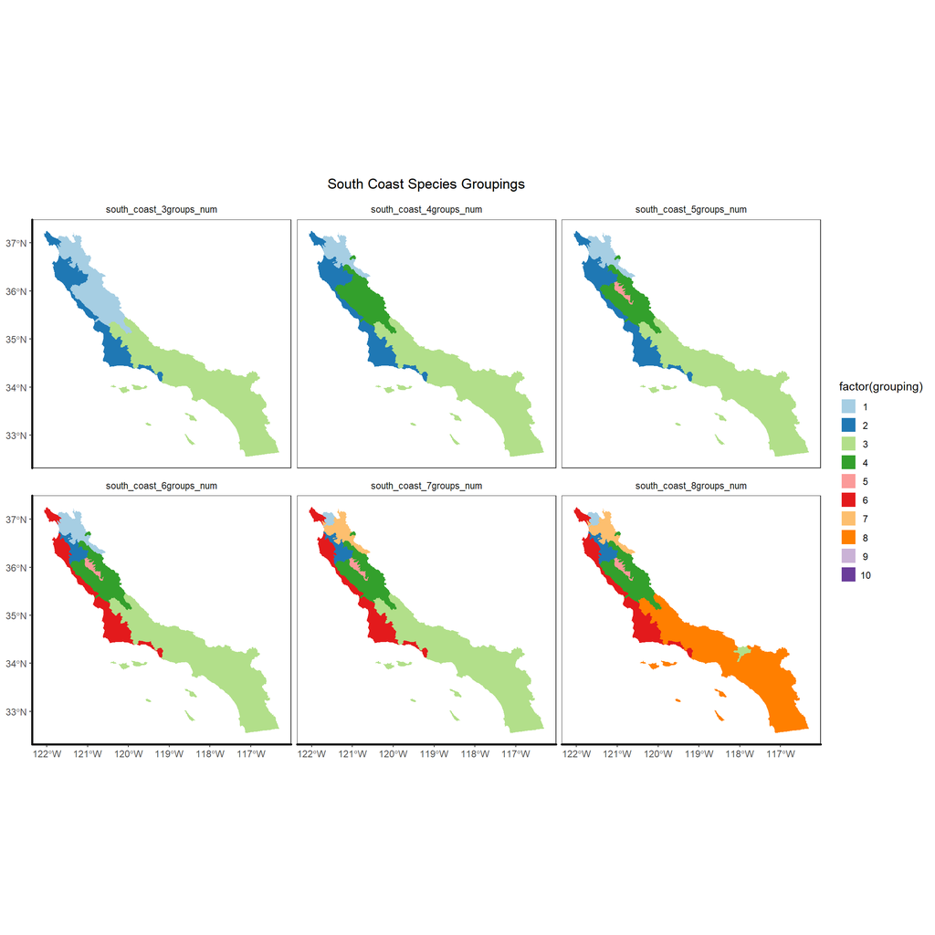

```r
soco_region_name = "south_coast"
soco_species_info <- species_maps(soco_region_name, "South Coast", huc_data)
soco_species_info$region_map  # print the map
```

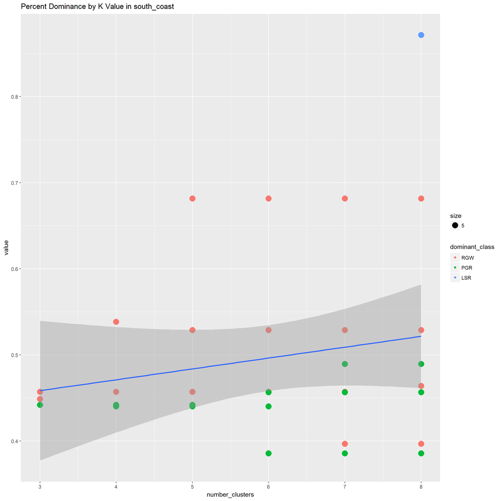

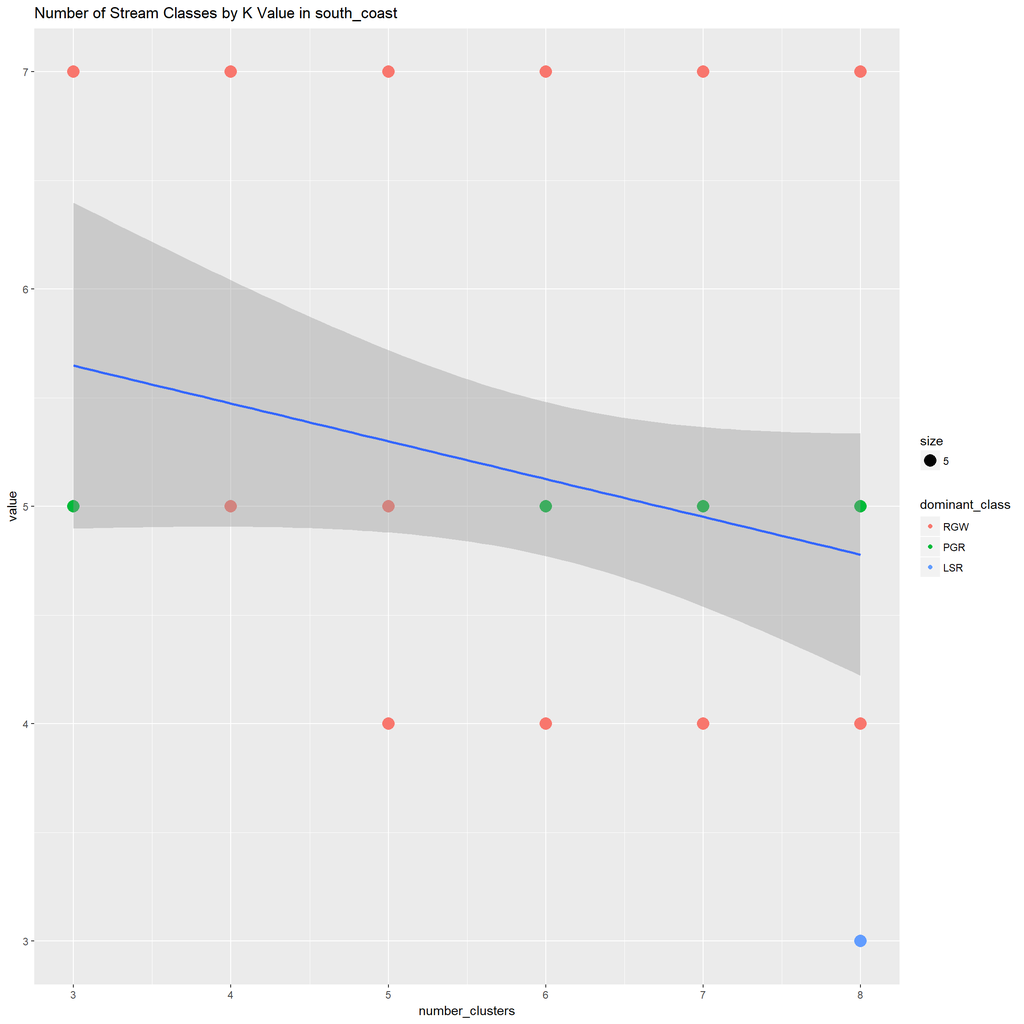

```r
print_dominance_plots(soco_species_info, soco_region_name)
```

```r
soco_species_lists <- species_lists_by_group_dfs(soco_species_info$species_data, soco_region_name)  # species_info$species_data is the data frame for the region
for(df in soco_species_lists){
  show(knitr::kable(df, format="html"))
}
```

| group_1 | group_2 | group_3 |
| --- | --- | --- |
| catostomus | catostomus | catostomus |
| cottus | entosphenus | entosphenus |
| entosphenus | eucyclogobius | eucyclogobius |
| eucyclogobius | gasterosteus | gasterosteus |
| gasterosteus | hesperoleucus | gila |
| hesperoleucus | lavinia | oncorhynchus |
| lavinia | oncorhynchus | ptychocheilus |
| oncorhynchus | ptychocheilus | rhinichthys |
| ptychocheilus | rhinichthys | NA |
| rhinichthys | NA | NA |

| group_1 | group_2 | group_3 | group_4 |
| --- | --- | --- | --- |
| catostomus | catostomus | catostomus | catostomus |
| cottus | entosphenus | entosphenus | cottus |
| entosphenus | eucyclogobius | eucyclogobius | entosphenus |
| eucyclogobius | gasterosteus | gasterosteus | gasterosteus |
| gasterosteus | hesperoleucus | gila | lavinia |
| hesperoleucus | lavinia | oncorhynchus | oncorhynchus |
| lavinia | oncorhynchus | ptychocheilus | ptychocheilus |
| oncorhynchus | ptychocheilus | rhinichthys | NA |
| ptychocheilus | rhinichthys | NA | NA |
| rhinichthys | NA | NA | NA |

| group_1 | group_2 | group_3 | group_4 | group_5 |
| --- | --- | --- | --- | --- |
| catostomus | catostomus | catostomus | catostomus | catostomus |
| cottus | entosphenus | entosphenus | entosphenus | cottus |
| entosphenus | eucyclogobius | eucyclogobius | lavinia | entosphenus |
| eucyclogobius | gasterosteus | gasterosteus | oncorhynchus | gasterosteus |
| gasterosteus | hesperoleucus | gila | ptychocheilus | lavinia |
| hesperoleucus | lavinia | oncorhynchus | NA | oncorhynchus |
| lavinia | oncorhynchus | ptychocheilus | NA | ptychocheilus |
| oncorhynchus | ptychocheilus | rhinichthys | NA | NA |
| ptychocheilus | rhinichthys | NA | NA | NA |
| rhinichthys | NA | NA | NA | NA |

| group_1 | group_2 | group_3 | group_4 | group_5 | group_6 |
| --- | --- | --- | --- | --- | --- |
| catostomus | catostomus | catostomus | catostomus | catostomus | catostomus |
| cottus | entosphenus | entosphenus | entosphenus | cottus | entosphenus |
| entosphenus | eucyclogobius | eucyclogobius | lavinia | entosphenus | eucyclogobius |
| eucyclogobius | gasterosteus | gasterosteus | oncorhynchus | gasterosteus | gasterosteus |
| gasterosteus | hesperoleucus | gila | ptychocheilus | lavinia | hesperoleucus |
| hesperoleucus | lavinia | oncorhynchus | NA | oncorhynchus | oncorhynchus |
| lavinia | oncorhynchus | ptychocheilus | NA | ptychocheilus | ptychocheilus |
| oncorhynchus | ptychocheilus | rhinichthys | NA | NA | rhinichthys |
| ptychocheilus | rhinichthys | NA | NA | NA | NA |
| rhinichthys | NA | NA | NA | NA | NA |

| group_1 | group_2 | group_3 | group_4 | group_5 | group_6 | group_7 |
| --- | --- | --- | --- | --- | --- | --- |
| catostomus | catostomus | catostomus | catostomus | catostomus | catostomus | catostomus |
| cottus | entosphenus | entosphenus | entosphenus | cottus | entosphenus | entosphenus |
| entosphenus | eucyclogobius | eucyclogobius | lavinia | entosphenus | eucyclogobius | eucyclogobius |
| eucyclogobius | gasterosteus | gasterosteus | oncorhynchus | gasterosteus | gasterosteus | gasterosteus |
| gasterosteus | hesperoleucus | gila | ptychocheilus | lavinia | hesperoleucus | hesperoleucus |
| hesperoleucus | lavinia | oncorhynchus | NA | oncorhynchus | oncorhynchus | lavinia |
| lavinia | oncorhynchus | ptychocheilus | NA | ptychocheilus | ptychocheilus | oncorhynchus |
| oncorhynchus | ptychocheilus | rhinichthys | NA | NA | rhinichthys | ptychocheilus |
| ptychocheilus | rhinichthys | NA | NA | NA | NA | rhinichthys |
| rhinichthys | NA | NA | NA | NA | NA | NA |

| group_1 | group_2 | group_3 | group_4 | group_5 | group_6 | group_7 | group_8 |
| --- | --- | --- | --- | --- | --- | --- | --- |
| catostomus | catostomus | catostomus | catostomus | catostomus | catostomus | catostomus | catostomus |
| cottus | entosphenus | gila | entosphenus | cottus | entosphenus | entosphenus | entosphenus |
| entosphenus | eucyclogobius | rhinichthys | lavinia | entosphenus | eucyclogobius | eucyclogobius | eucyclogobius |
| eucyclogobius | gasterosteus | NA | oncorhynchus | gasterosteus | gasterosteus | gasterosteus | gasterosteus |
| gasterosteus | hesperoleucus | NA | ptychocheilus | lavinia | hesperoleucus | hesperoleucus | gila |
| hesperoleucus | lavinia | NA | NA | oncorhynchus | oncorhynchus | lavinia | oncorhynchus |
| lavinia | oncorhynchus | NA | NA | ptychocheilus | ptychocheilus | oncorhynchus | ptychocheilus |
| oncorhynchus | ptychocheilus | NA | NA | NA | rhinichthys | ptychocheilus | rhinichthys |
| ptychocheilus | rhinichthys | NA | NA | NA | NA | rhinichthys | NA |
| rhinichthys | NA | NA | NA | NA | NA | NA | NA |